# 3,4일차

## 외부 파일 읽어오기

- .csv, .json, .xlsx

#### CSV 파일

- Comma Separated Values

```python
import pandas as pd
```

```python
df = pd.read_csv('test1.csv', index_col = 'datetime')
df
```

| datetime | season | holiday | workingday | weather | temp | atemp | humidity | windspeed | casual | registered | count |
| --- | --- | --- | --- | --- | --- | --- | --- | --- | --- | --- | --- |
| 2011-01-01 00:00:00 | 1 | 0 | 0 | 1 | 9.84 | 14.395 | 81 | 0.0000 | 3 | 13 | 16 |
| 2011-01-01 01:00:00 | 1 | 0 | 0 | 1 | 9.02 | 13.635 | 80 | 0.0000 | 8 | 32 | 40 |
| 2011-01-01 02:00:00 | 1 | 0 | 0 | 1 | 9.02 | 13.635 | 80 | 0.0000 | 5 | 27 | 32 |
| 2011-01-01 03:00:00 | 1 | 0 | 0 | 1 | 9.84 | 14.395 | 75 | 0.0000 | 3 | 10 | 13 |
| 2011-01-01 04:00:00 | 1 | 0 | 0 | 1 | 9.84 | 14.395 | 75 | 0.0000 | 0 | 1 | 1 |
| ... | ... | ... | ... | ... | ... | ... | ... | ... | ... | ... | ... |
| 2012-12-19 19:00:00 | 4 | 0 | 1 | 1 | 15.58 | 19.695 | 50 | 26.0027 | 7 | 329 | 336 |
| 2012-12-19 20:00:00 | 4 | 0 | 1 | 1 | 14.76 | 17.425 | 57 | 15.0013 | 10 | 231 | 241 |
| 2012-12-19 21:00:00 | 4 | 0 | 1 | 1 | 13.94 | 15.910 | 61 | 15.0013 | 4 | 164 | 168 |
| 2012-12-19 22:00:00 | 4 | 0 | 1 | 1 | 13.94 | 17.425 | 61 | 6.0032 | 12 | 117 | 129 |
| 2012-12-19 23:00:00 | 4 | 0 | 1 | 1 | 13.12 | 16.665 | 66 | 8.9981 | 4 | 84 | 88 |

10886 rows × 11 columns

```python
data = {'name': ['jo', 'kim', 'lee'],
       'python': ['A', 'A+', 'B+'],
       'C++': ['B+', 'B+', 'A'],
       'java': ['C+', 'A+', 'A']}

df = pd.DataFrame(data)
df.set_index('name', inplace=True)
df.to_csv('csv_sample.csv')
```

```python
df = pd.read_csv('test1.csv')
df.head()
```

|  | datetime | season | holiday | workingday | weather | temp | atemp | humidity | windspeed | casual | registered | count |
| --- | --- | --- | --- | --- | --- | --- | --- | --- | --- | --- | --- | --- |
| 0 | 2011-01-01 00:00:00 | 1 | 0 | 0 | 1 | 9.84 | 14.395 | 81 | 0.0 | 3 | 13 | 16 |
| 1 | 2011-01-01 01:00:00 | 1 | 0 | 0 | 1 | 9.02 | 13.635 | 80 | 0.0 | 8 | 32 | 40 |
| 2 | 2011-01-01 02:00:00 | 1 | 0 | 0 | 1 | 9.02 | 13.635 | 80 | 0.0 | 5 | 27 | 32 |
| 3 | 2011-01-01 03:00:00 | 1 | 0 | 0 | 1 | 9.84 | 14.395 | 75 | 0.0 | 3 | 10 | 13 |
| 4 | 2011-01-01 04:00:00 | 1 | 0 | 0 | 1 | 9.84 | 14.395 | 75 | 0.0 | 0 | 1 | 1 |

```python
df.columns
```

```
Index(['datetime', 'season', 'holiday', 'workingday', 'weather', 'temp',
       'atemp', 'humidity', 'windspeed', 'casual', 'registered', 'count'],
      dtype='object')
```

- 출처: https://ride.capitalbikeshare.com/system-data
- 2011~2012년도까지 2년치, 시간대별로
- 날짜정보: 'datetime', 'season', 'holiday', 'workingday'
- 기상정보: 'weather', 'temp', 'atemp', 'humidity', 'windspeed'
- 고객정보: 'casual', 'registered', 'count'

```python
#df.head(3)
df[0:3]
```

|  | datetime | season | holiday | workingday | weather | temp | atemp | humidity | windspeed | casual | registered | count |
| --- | --- | --- | --- | --- | --- | --- | --- | --- | --- | --- | --- | --- |
| 0 | 2011-01-01 00:00:00 | 1 | 0 | 0 | 1 | 9.84 | 14.395 | 81 | 0.0 | 3 | 13 | 16 |
| 1 | 2011-01-01 01:00:00 | 1 | 0 | 0 | 1 | 9.02 | 13.635 | 80 | 0.0 | 8 | 32 | 40 |
| 2 | 2011-01-01 02:00:00 | 1 | 0 | 0 | 1 | 9.02 | 13.635 | 80 | 0.0 | 5 | 27 | 32 |

```python
df.tail()
```

|  | datetime | season | holiday | workingday | weather | temp | atemp | humidity | windspeed | casual | registered | count |
| --- | --- | --- | --- | --- | --- | --- | --- | --- | --- | --- | --- | --- |
| 10881 | 2012-12-19 19:00:00 | 4 | 0 | 1 | 1 | 15.58 | 19.695 | 50 | 26.0027 | 7 | 329 | 336 |
| 10882 | 2012-12-19 20:00:00 | 4 | 0 | 1 | 1 | 14.76 | 17.425 | 57 | 15.0013 | 10 | 231 | 241 |
| 10883 | 2012-12-19 21:00:00 | 4 | 0 | 1 | 1 | 13.94 | 15.910 | 61 | 15.0013 | 4 | 164 | 168 |
| 10884 | 2012-12-19 22:00:00 | 4 | 0 | 1 | 1 | 13.94 | 17.425 | 61 | 6.0032 | 12 | 117 | 129 |
| 10885 | 2012-12-19 23:00:00 | 4 | 0 | 1 | 1 | 13.12 | 16.665 | 66 | 8.9981 | 4 | 84 | 88 |

```python
df.shape
```

```
(10886, 12)
```

```python
df.info()
```

```
<class 'pandas.core.frame.DataFrame'>
RangeIndex: 10886 entries, 0 to 10885
Data columns (total 12 columns):
 #   Column      Non-Null Count  Dtype
---  ------      --------------  -----
 0   datetime    10886 non-null  object
 1   season      10886 non-null  int64
 2   holiday     10886 non-null  int64
 3   workingday  10886 non-null  int64
 4   weather     10886 non-null  int64
 5   temp        10886 non-null  float64
 6   atemp       10886 non-null  float64
 7   humidity    10886 non-null  int64
 8   windspeed   10886 non-null  float64
 9   casual      10886 non-null  int64
 10  registered  10886 non-null  int64
 11  count       10886 non-null  int64
dtypes: float64(3), int64(8), object(1)
memory usage: 1020.7+ KB
```

```python
df.describe()
```

|  | season | holiday | workingday | weather | temp | atemp | humidity | windspeed | casual | registered | count |
| --- | --- | --- | --- | --- | --- | --- | --- | --- | --- | --- | --- |
| count | 10886.000000 | 10886.000000 | 10886.000000 | 10886.000000 | 10886.00000 | 10886.000000 | 10886.000000 | 10886.000000 | 10886.000000 | 10886.000000 | 10886.000000 |
| mean | 2.506614 | 0.028569 | 0.680875 | 1.418427 | 20.23086 | 23.655084 | 61.886460 | 12.799395 | 36.021955 | 155.552177 | 191.574132 |
| std | 1.116174 | 0.166599 | 0.466159 | 0.633839 | 7.79159 | 8.474601 | 19.245033 | 8.164537 | 49.960477 | 151.039033 | 181.144454 |
| min | 1.000000 | 0.000000 | 0.000000 | 1.000000 | 0.82000 | 0.760000 | 0.000000 | 0.000000 | 0.000000 | 0.000000 | 1.000000 |
| 25% | 2.000000 | 0.000000 | 0.000000 | 1.000000 | 13.94000 | 16.665000 | 47.000000 | 7.001500 | 4.000000 | 36.000000 | 42.000000 |
| 50% | 3.000000 | 0.000000 | 1.000000 | 1.000000 | 20.50000 | 24.240000 | 62.000000 | 12.998000 | 17.000000 | 118.000000 | 145.000000 |
| 75% | 4.000000 | 0.000000 | 1.000000 | 2.000000 | 26.24000 | 31.060000 | 77.000000 | 16.997900 | 49.000000 | 222.000000 | 284.000000 |
| max | 4.000000 | 1.000000 | 1.000000 | 4.000000 | 41.00000 | 45.455000 | 100.000000 | 56.996900 | 367.000000 | 886.000000 | 977.000000 |

```python
df.describe(include='all')
```

|  | datetime | season | holiday | workingday | weather | temp | atemp | humidity | windspeed | casual | registered | count |
| --- | --- | --- | --- | --- | --- | --- | --- | --- | --- | --- | --- | --- |
| count | 10886 | 10886.000000 | 10886.000000 | 10886.000000 | 10886.000000 | 10886.00000 | 10886.000000 | 10886.000000 | 10886.000000 | 10886.000000 | 10886.000000 | 10886.000000 |
| unique | 10886 | NaN | NaN | NaN | NaN | NaN | NaN | NaN | NaN | NaN | NaN | NaN |
| top | 2011-01-01 00:00:00 | NaN | NaN | NaN | NaN | NaN | NaN | NaN | NaN | NaN | NaN | NaN |
| freq | 1 | NaN | NaN | NaN | NaN | NaN | NaN | NaN | NaN | NaN | NaN | NaN |
| mean | NaN | 2.506614 | 0.028569 | 0.680875 | 1.418427 | 20.23086 | 23.655084 | 61.886460 | 12.799395 | 36.021955 | 155.552177 | 191.574132 |
| std | NaN | 1.116174 | 0.166599 | 0.466159 | 0.633839 | 7.79159 | 8.474601 | 19.245033 | 8.164537 | 49.960477 | 151.039033 | 181.144454 |
| min | NaN | 1.000000 | 0.000000 | 0.000000 | 1.000000 | 0.82000 | 0.760000 | 0.000000 | 0.000000 | 0.000000 | 0.000000 | 1.000000 |
| 25% | NaN | 2.000000 | 0.000000 | 0.000000 | 1.000000 | 13.94000 | 16.665000 | 47.000000 | 7.001500 | 4.000000 | 36.000000 | 42.000000 |
| 50% | NaN | 3.000000 | 0.000000 | 1.000000 | 1.000000 | 20.50000 | 24.240000 | 62.000000 | 12.998000 | 17.000000 | 118.000000 | 145.000000 |
| 75% | NaN | 4.000000 | 0.000000 | 1.000000 | 2.000000 | 26.24000 | 31.060000 | 77.000000 | 16.997900 | 49.000000 | 222.000000 | 284.000000 |
| max | NaN | 4.000000 | 1.000000 | 1.000000 | 4.000000 | 41.00000 | 45.455000 | 100.000000 | 56.996900 | 367.000000 | 886.000000 | 977.000000 |

```python
df.count()
```

```
datetime      10886
season        10886
holiday       10886
workingday    10886
weather       10886
temp          10886
atemp         10886
humidity      10886
windspeed     10886
casual        10886
registered    10886
count         10886
dtype: int64
```

```python
df['weather'].value_counts()
```

```
1    7192
2    2834
3     859
4       1
Name: weather, dtype: int64
```

```python
df['count'].mean()
```

```
191.57413191254824
```

```python
df.mean()
```

```
season          2.506614
holiday         0.028569
workingday      0.680875
weather         1.418427
temp           20.230860
atemp          23.655084
humidity       61.886460
windspeed      12.799395
casual         36.021955
registered    155.552177
count         191.574132
dtype: float64
```

```python
df['count'].median()
```

```
145.0
```

```python
df['count'].max()
```

```
977
```

```python
df['count'].min()
```

```
1
```

```python
df['count'].std()

# 표준편차(Standard Deviation): 데이터가 평균 주변에 얼마나 모여있는지,
#                                혹은 흩어져 있는지(산포도)
```

```
181.14445383028496
```

```python
# 상관계수(coefficient of correlation)
df[['weather', 'count']].corr()
```

|  | weather | count |
| --- | --- | --- |
| weather | 1.000000 | -0.128655 |
| count | -0.128655 | 1.000000 |

```python
# 데이터 처음 불러올 때 주로 묶어서 사용하는 세트메뉴
import pandas as pd # module import

df = pd.read_csv('test1.csv') # 데이터셋 읽기
print(df.shape) # 대략적인 크기 확인
df.head(3).T # column 당 어떤 값이 들어있는지 눈으로 확인
```

```
(10886, 12)
```

|  | 0 | 1 | 2 |
| --- | --- | --- | --- |
| datetime | 2011-01-01 00:00:00 | 2011-01-01 01:00:00 | 2011-01-01 02:00:00 |
| season | 1 | 1 | 1 |
| holiday | 0 | 0 | 0 |
| workingday | 0 | 0 | 0 |
| weather | 1 | 1 | 1 |
| temp | 9.84 | 9.02 | 9.02 |
| atemp | 14.395 | 13.635 | 13.635 |
| humidity | 81 | 80 | 80 |
| windspeed | 0.0 | 0.0 | 0.0 |
| casual | 3 | 8 | 5 |
| registered | 13 | 32 | 27 |
| count | 16 | 40 | 32 |

## 시각화(Visualization)

- 좋은 시각화 자료는 직관성 + 시인성
- 대상군(audience): stakeholder, sponsor, technical audience
- pandas, matplotlib, seaborn 등 다양한 도구로 시각화 가능

```python
import pandas as pd

df = pd.read_excel('남북한발전전력량.xlsx')

df = df.iloc[[0, 5], 2:]
df.index = ['South', 'North']
df
```

|  | 1990 | 1991 | 1992 | 1993 | 1994 | 1995 | 1996 | 1997 | 1998 | 1999 | ... | 2007 | 2008 | 2009 | 2010 | 2011 | 2012 | 2013 | 2014 | 2015 | 2016 |
| --- | --- | --- | --- | --- | --- | --- | --- | --- | --- | --- | --- | --- | --- | --- | --- | --- | --- | --- | --- | --- | --- |
| South | 1077 | 1186 | 1310 | 1444 | 1650 | 1847 | 2055 | 2244 | 2153 | 2393 | ... | 4031 | 4224 | 4336 | 4747 | 4969 | 5096 | 5171 | 5220 | 5281 | 5404 |
| North | 277 | 263 | 247 | 221 | 231 | 230 | 213 | 193 | 170 | 186 | ... | 236 | 255 | 235 | 237 | 211 | 215 | 221 | 216 | 190 | 239 |

2 rows × 27 columns

```python
df.columns
```

```
Index(['1990', '1991', '1992', '1993', '1994', '1995', '1996', '1997', '1998',
       '1999', '2000', '2001', '2002', '2003', '2004', '2005', '2006', '2007',
       '2008', '2009', '2010', '2011', '2012', '2013', '2014', '2015', '2016'],
      dtype='object')
```

```python
df.columns = df.columns.map(int)
df.columns
```

```
Int64Index([1990, 1991, 1992, 1993, 1994, 1995, 1996, 1997, 1998, 1999, 2000,
            2001, 2002, 2003, 2004, 2005, 2006, 2007, 2008, 2009, 2010, 2011,
            2012, 2013, 2014, 2015, 2016],
           dtype='int64')
```

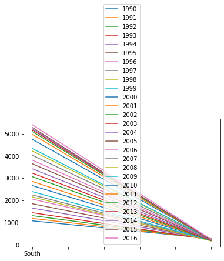

```python
df.plot()
```

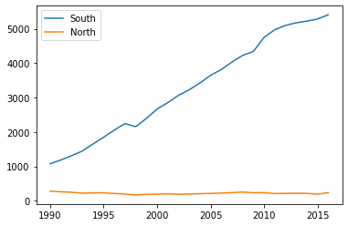

```python
df.T.plot()
```

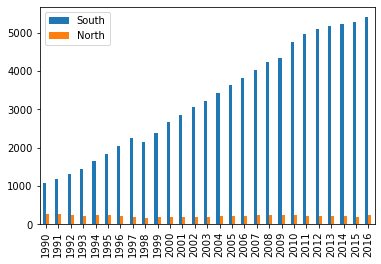

```python
df.T.plot(kind='bar')
```

## matplotlib

- 문서: https://matplotlib.org/stable/gallery/index

```python
import pandas as pd

df = pd.read_csv('test1.csv')
df.head(3)
```

|  | datetime | season | holiday | workingday | weather | temp | atemp | humidity | windspeed | casual | registered | count |
| --- | --- | --- | --- | --- | --- | --- | --- | --- | --- | --- | --- | --- |
| 0 | 2011-01-01 00:00:00 | 1 | 0 | 0 | 1 | 9.84 | 14.395 | 81 | 0.0 | 3 | 13 | 16 |
| 1 | 2011-01-01 01:00:00 | 1 | 0 | 0 | 1 | 9.02 | 13.635 | 80 | 0.0 | 8 | 32 | 40 |
| 2 | 2011-01-01 02:00:00 | 1 | 0 | 0 | 1 | 9.02 | 13.635 | 80 | 0.0 | 5 | 27 | 32 |

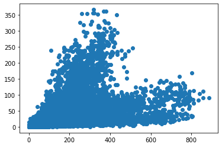

```python
import matplotlib.pyplot as plt

plt.scatter(data=df, x='registered', y='casual')
```

## seaborn

- matplolib의 기능과 스타일을 확장한 파이썬 시각화 도구의 고급 버전
- hue 기능 활용
- 문서: https://seaborn.pydata.org/tutorial.html

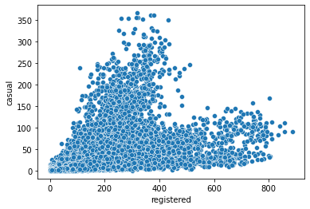

```python
import seaborn as sns

sns.scatterplot(data=df, x='registered', y='casual')
```

#### seaborn의 hue 기능

- 그래프에 색을 추가해 정보를 그래프에 반영

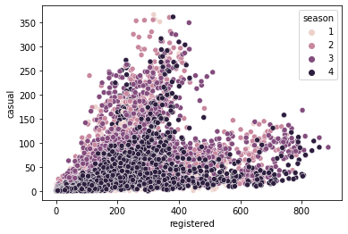

```python
sns.scatterplot(data=df, x='registered', y='casual', hue='season')

# season은 4가지 경우 수가 있는데 이것을 구분해 색상별로 표현
# 계절 별로 사용량의 차이가 있지만 전체적으로 유사함
```

```python
df.columns
```

```
Index(['datetime', 'season', 'holiday', 'workingday', 'weather', 'temp',
       'atemp', 'humidity', 'windspeed', 'casual', 'registered', 'count'],
      dtype='object')
```

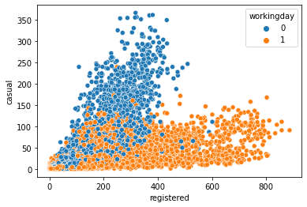

```python
# Q1) 일하는 날과 일하지 않는 날에 따라 회원별 사용하는 날의 차이가
#     있을 것으로 예상된다. 이에 대한 그래프를 그리세요.
sns.scatterplot(data=df, x='registered', y='casual', hue='workingday')

# 일하는 날에는 등록 회원이 많이 이용하고,
# 일하지 않는 날에는 비등록 회원이 많이 이용한다.
# 등록 회원과 비등록 회원이 사용하는 빈도의 차이는
# 일하는 날과 일하지 않는 날의 차이이다.

# 데이터 표현하고, 해석하는 그림을 통해 데이터를 잘 표현하는 문장을 도출
```

```python
df.columns
```

```
Index(['datetime', 'season', 'holiday', 'workingday', 'weather', 'temp',
       'atemp', 'humidity', 'windspeed', 'casual', 'registered', 'count'],
      dtype='object')
```

```python
df.head(3)
```

|  | datetime | season | holiday | workingday | weather | temp | atemp | humidity | windspeed | casual | registered | count |
| --- | --- | --- | --- | --- | --- | --- | --- | --- | --- | --- | --- | --- |
| 0 | 2011-01-01 00:00:00 | 1 | 0 | 0 | 1 | 9.84 | 14.395 | 81 | 0.0 | 3 | 13 | 16 |
| 1 | 2011-01-01 01:00:00 | 1 | 0 | 0 | 1 | 9.02 | 13.635 | 80 | 0.0 | 8 | 32 | 40 |
| 2 | 2011-01-01 02:00:00 | 1 | 0 | 0 | 1 | 9.02 | 13.635 | 80 | 0.0 | 5 | 27 | 32 |

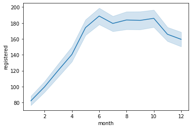

```python
# Q2) 월별 등록 회원의 이용량 그래프를 작성하세요.

df = pd.read_csv('test1_modify.csv')
sns.lineplot(data=df, x='month', y='registered')
```

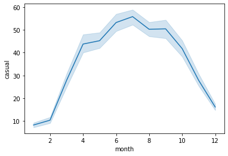

```python
# Q3) 월별 비등록 회원의 이용량 그래프를 작성하고, 회원별 사용편차에 대해 기술하세요.
sns.lineplot(data=df, x='month', y='casual')

# 등록 회원에 비해 비등록 회원은 월별 사용편차가 심함
```

```python
df.columns
```

```
Index(['season', 'holiday', 'workingday', 'weather', 'temp', 'atemp',
       'humidity', 'windspeed', 'casual', 'registered', 'count', 'year',
       'month', 'day', 'hour', 'dayofweek'],
      dtype='object')
```

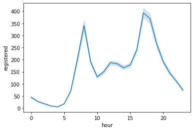

```python
# Q4) 사람의 행동 패턴의 가장 큰 영향을 미치는 시간이다.
#     시간대별 회원들의 패턴을 확인하세요.
sns.lineplot(data=df, x='hour', y='registered')
```

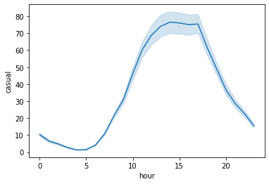

```python
sns.lineplot(data=df, x='hour', y='casual')

# 등록 회원과 비등록 회원은 사용 의도와 목적이 다를 것
```

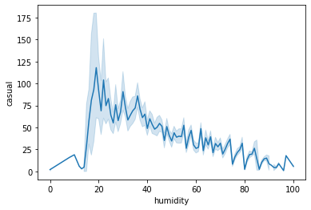

```python
sns.lineplot(data=df, x='humidity', y='casual')
```

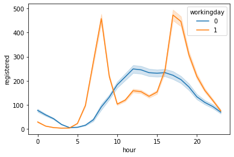

```python
# Q5) Q4에서 일하는 날과 노는 날을 기준으로
#     일하는 날에서만 나타나는 패턴인지, 일 안하는 날에도 똑같은 패턴인지 확인
sns.lineplot(data=df, x='hour', y='registered', hue='workingday')

# 등록 회원은 일하는 날 출퇴근 시간대에 이용량이 높고, 노는 날엔 상반된 결과를 보임
```

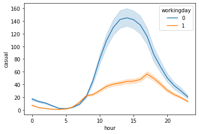

```python
sns.lineplot(data=df, x='hour', y='casual', hue='workingday')

# 비등록 회원은 일하는 날 사용량이 낮고, 노는 날 점심 시간대에 이용량이 가장 높음
```

## 데이터 분석 절차, 단계, 방법론

- KDD, CRISP-DM

## CRISP-DM

- Cross Inderstry Standard Process - Data Mining
- 가장 많이 사용되는 Data Mining 표준 방법론
- 분야, 산업군을 막론하고 데이터로부터 의미를 도출하는 표준 절차

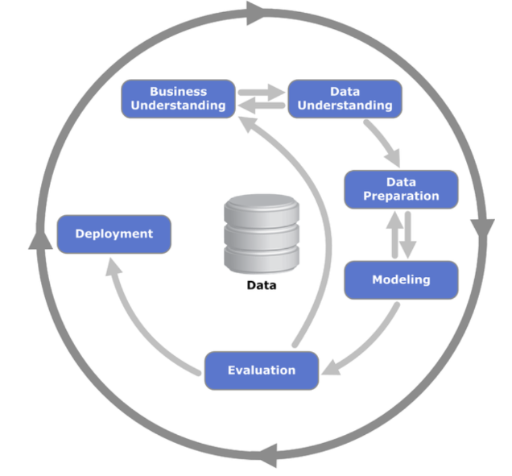

## Business Understanding

- 분석할 분야의 목적과 요구사항을 이해하고, 초기 프로젝트 계획을 수립하는 단계
- 업무 목적과 상황을 파악, 프로젝트 계획 수립 등의 세부 업무 포함
- 해당 분야의 종사자들이 원하는 방향
- 분야별로 관심사가 다름
- 과거 학술, 기술적으로 선행연구가 무엇이었는지를 파악
- 분석 방향성 및 목표 설정

## Data Understanding

- 데이터 수집, 데이터 속성을 이해하는 단계
- 가용 데이터로 기존에 설정한 분석 방향성 및 목표 달성이 가능할지 여부 파악
- 데이터 품질 확인

#### EDA(Exploratory Data Analysis)

- 시각화를 통해 데이터 안의 유효한 패턴(인사이트)을 확인 가능하게 만듦
- 수집한 데이터를 관찰하고 이해하는 과정
1. 데이터의 출처와 주제에 대한 이해
2. 데이터의 크기 확인
3. 데이터의 구성 요소 확인
4. 탐색한 데이터의 시각화

## Data Preparation

- 분석 기법에 적합 데이터를 편성하는 단계, 데이터셋 선택, 데이터 정제 등
- 모델링(Machine Learning)을 대비하는 단계
- 알고리즘에 넣을 데이터를 '적절하게' 준비

#### Machine Learning

- 지도 학습: 문제와 정답(label)이 있음, 데이터의 정답을 알려줌
- 비지도 학습: 문제만 있고, 정답은 없음, 데이터를 보고 스스로 구분
- 학습용(train)과 시험용(test) 데이터셋 분리(split)
- 학습했던 문제가 시험문제에 똑같이 나오면 시험 점수를 신뢰할 수 없음
- 데이터셋 분리는 공부했던 문제가 시험문제에 나오지 않게 하기 위함

## Modeling

- 다양한 modeling 기법과 알고리즘을 선택하고, 사용되는 파라미터들을 최적화하는 단계
- 모델의 성능을 평가하고, overfitting 되었는지 확인

#### Overfitting

- train 데이터에만 최적화 되는 것

#### Planning

- 속도, 예측력, 해석력
- 내부 계산과정이 복잡할수록 속도 ↓, 예측력 ↑, 해석력 ↓
- 일반적으로 기술통계 분야 알고리즘은 속도와 해석력이 우수함

#### Building

- palnning 단계에서 고른 알고리즘에 학습용 데이터로 학습시키고, 시험용 데이터로 채점
- 채점 시 관점에 따라 평가지표가 달라짐
- 경우1) 정답 1, 예측값 2
- 경우2) 정답 1001, 예측값 1002

#### 평가지표

- 서로 다른 알고리즘 중에서 한 평가지표 기준으로 어떤 알고리즘의 정확도가 좋은가
- 한 알고리즘에 대해 옵션 설정하여 조금씩 다른 알고리즘 만들었을 때 상호비교용

## Evaluation

- Communicate Results
- modeling의 결과가 프로젝트 목적에 부합하는지를 평가
- Executive summary, Techinical Report 작성

## Deployment

- Operationalize
- 완성된 모델을 실제 업무에 적용하기 위한 단계
- 모니터링과 모델의 유지보수 계획 마련